# Sta112FS 7. The language of models

Dr. Çetinkaya-Rundel

September 17, 2015

# Today’s agenda

## Today’s agenda

- Review App Ex from last time
- Modeling the relationship between variables
  - Focus on *linear* models (but remember there are other types of models too!)
- Application Exercise: model prices of Paris Paintings
- **Due Tuesday:** Finish App Ex + Reading (you’ll receive an email with a link after class)

# Prepping the data

## Load packages + Paris Paintings data

```r
library(ggplot2)
library(dplyr)
library(stringr)
```

```r
pp <- read.csv("paris_paintings.csv", stringsAsFactors = FALSE) %>%
  tbl_df()
```

## What’s going on with prices?

```r
class(pp$price)
```

```
## [1] "character"
```

```r
table(pp$price)[1:30]
```

```
##
## 1,000.0 1,000.4 1,001.0 1,002.0 1,004.0 1,005.0 1,006.0 1,008.0 1,011.0 1,035.5 1,050.0 1,051.0
##      20       1       4       4       1       1       2       1       1       2       4       1
## 1,055.0 1,060.0 1,077.0 1,079.0 1,080.0 1,086.0 1,099.0 1,100.0 1,100.5 1,105.0 1,110.0 1,140.0
##       2       1       1       1       1       1       1       6       2       1       2       1
## 1,150.0 1,155.0 1,161.0 1,180.0 1,200.0 1,201.0
##       4       2       1       3      14       5
```

## Let’s first fix those prices

Replace `,` with `` (blank), and save the variable as numeric:

```r
pp <- pp %>%
  mutate(price = as.numeric(str_replace(price, ",", "")))
```

Much better…

```r
class(pp$price)
```

```
## [1] "numeric"
```

## Prices

Describe the distribution of prices of paintings.

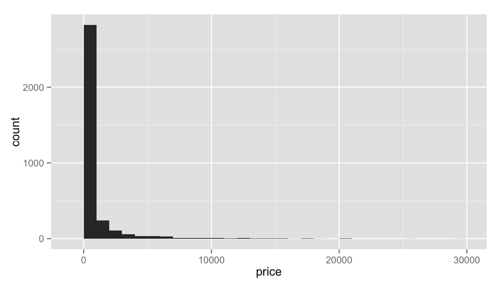

```r
ggplot(data = pp, aes(x = price)) +
  geom_histogram(binwidth = 1000)
```

# Modeling the relationship between variables

## Models as functions

- We can represent relationships between variables using **function**
- A function is a mathematical concept: the relationship between an output and one or more inputs.
  - Plug in the inputs and receive back the output
  - Example: the formula $y = 3x + 7$ is a function with input $x$ and output $y$, when $x$ is $5$, the output $y$ is $22$

## Height as a function of width

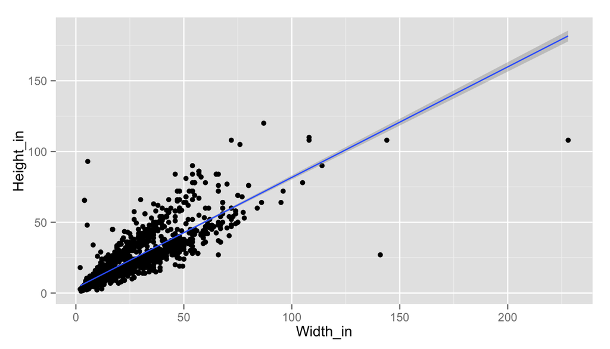

```r
ggplot(data = pp, aes(x = Width_in, y = Height_in)) +
  geom_point() +
  stat_smooth(method = "lm") # lm for linear model
```

## Vocabulary

- **Response variable:** Variable whose behavior or variation you are trying to understand, on the y-axis (dependent variable)
- **Explanatory variables:** Other variables that you want to use to explain the variation in the response, on the x-axis (independent variables)
- **Model value:** Output of the function **model function**
  - The model function gives the typical value of the response variable *conditioning* on the explanatory variables
  - Also called the **predicted value**
- **Residuals:** Show how far each case is from its model value
  - $residual = actual~value - model~value$
  - Tells how far above the model function each case is

## Residuals

What does a negative residual mean? Which paintings on the plot have have negative residuals?

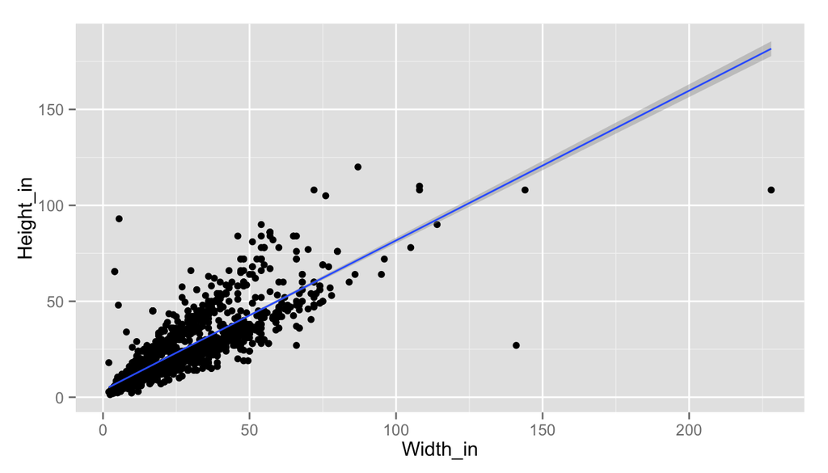

## Multiple explanatory variables

How, if at all, the relatonship between width and height of paintings vary by whether or not they have any landscape elements?

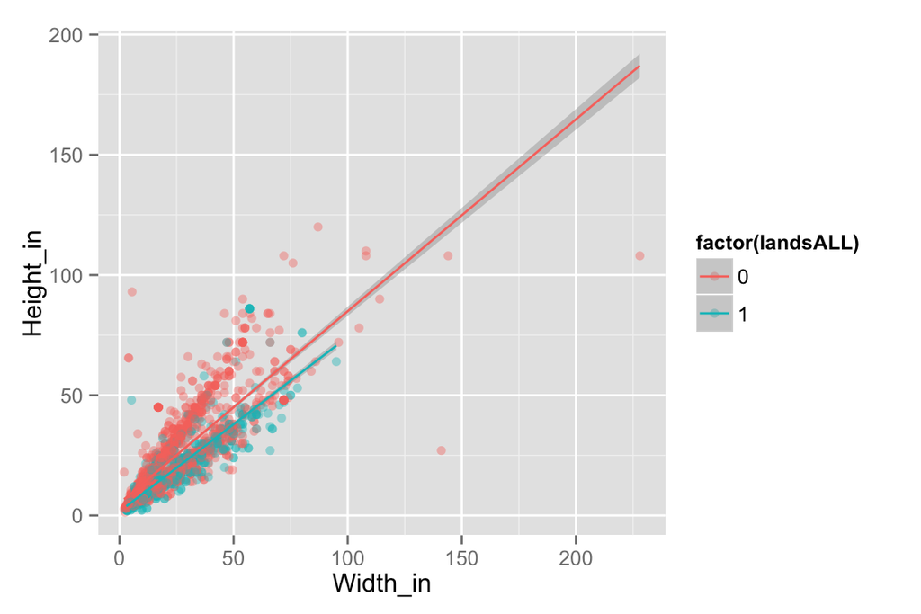

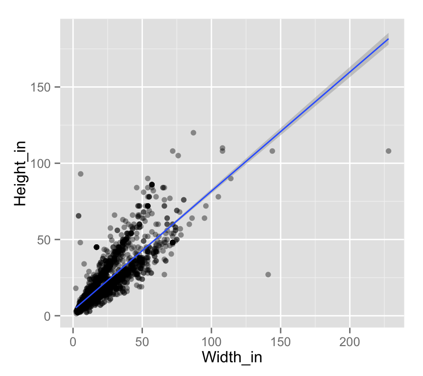

## Just for reference…

Here is the code for the two plots in the previous slide

```r
# points colored by landsALL type
ggplot(data = pp, aes(x = Width_in, y = Height_in, color = factor(landsALL))) +
  geom_point(alpha = 0.4) +
  stat_smooth(method = "lm")
```

```r
# points not colored by landsALL type
ggplot(data = pp, aes(x = Width_in, y = Height_in)) +
  geom_point(alpha = 0.4) +
  stat_smooth(method = "lm")
```

## Models - upsides and downsides

- Models can sometimes reveal patterns that are not evident in a graph of the data. This is a great advantage of modeling over simple visual inspection of data.
- There is a real risk, however, that a model is imposing structure that is not really there on the scatter of data, just as people imagine animal shapes in the stars. A skeptical approach is always warranted.

## Variation around the model…

is just as important as the model, if not more!

*Statistics is the explanation of variation in the context of what remains unexplained.*

- The scatter suggests that there might be other factors that account for large parts of painting-to-painting variability, or perhaps just that randomness plays a big role.
- Adding more explanatory variables to a model can sometimes usefully reduce the size of the scatter around the model. (We’ll talk more about this later.)

# How do we use models?

1. Explanation: Characterize the relationship between $y$ and $x$ via *slopes* for numerical explanatory variables or *differences* for categorical explanatory variables
2. Prediction: Plug in $x$, get the predicted $y$

# Characterizing relationships with models

## Relationship between height and width

```r
lm(Height_in ~ Width_in, data = pp)
```

```
##
## Call:
## lm(formula = Height_in ~ Width_in, data = pp)
##
## Coefficients:
## (Intercept)     Width_in
##      3.6214       0.7808
```

$\widehat{Height_{in}} = 3.62 + 0.78~Width_{in}$

- **Slope:** For each additional inch the painting is wider, the height is expected to be higher, on average, by 0.78 inches.
- **Intercept:** Paintings that are 0 inches wide are expected to be 3.62 inches high, on average.
  - Does this make sense?

## Relationship between height and landscape features

```r
lm(Height_in ~ factor(landsALL), data = pp)
```

```
##
## Call:
## lm(formula = Height_in ~ factor(landsALL), data = pp)
##
## Coefficients:
##       (Intercept)  factor(landsALL)1
##            22.680             -5.645
```

$\widehat{Height_{in}} = 22.68 - 5.65~landsALL$

- **Slope:** Paintings that have some landscape features are expected, on average, to be 5.65 inches shorter than paintings that don’t have landscape features.
  - Compares the baseline level (`landsALL = 0`) to the other level (`landsALL = 1`).
- **Intercept:** Paintings that don’t have landscape features are expected, on average, to be 22.68 inches tall.

## Relationship between height and school

```r
lm(Height_in ~ school_pntg, data = pp)
```

```
##
## Call:
## lm(formula = Height_in ~ school_pntg, data = pp)
##
## Coefficients:
##     (Intercept)  school_pntgD/FL     school_pntgF     school_pntgG     school_pntgI
##          14.000            2.329           10.197            1.650           10.287
##    school_pntgS     school_pntgX
##          30.429            2.869
```

- When the categorical explanatory variable has many levels, they’re encoded to **dummy variables**.
- Each coefficient describes the expected difference between heights in that particular school compared to the baseline level.

## Correlation does not imply causation!

Remember this when interpreting model coefficients

# Prediction with models

## Predict height from width

On average, how tall are paintings that are 60 inches wide? $\widehat{Height_{in}} = 3.62 + 0.78~Width_{in}$

```r
3.62 + 0.78 * 60
```

```
## [1] 50.42
```

“On average, we expect paintings that are 60 inches wide to be 50.42 inches high.”

**Warning:** We “expect” this to happen, but there will be some variability. (We’ll learn about measuring the variability around the prediction later.)

## Prediction vs. extrapolation

On average, how tall are paintings that are 400 inches wide? $\widehat{Height_{in}} = 3.62 + 0.78~Width_{in}$

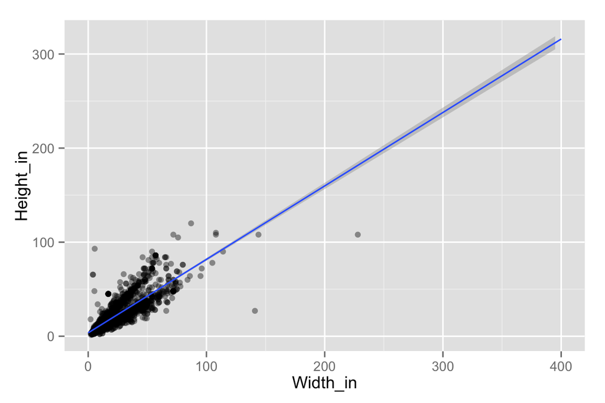

## Watch out for extrapolation!

“When those blizzards hit the East Coast this winter, it proved to my satisfaction that global warming was a fraud. That snow was freezing cold. But in an alarming trend, temperatures this spring have risen. Consider this: On February 6th it was 10 degrees. Today it hit almost 80. At this rate, by August it will be 220 degrees. So clearly folks the climate debate rages on.” - Stephen Colbert April 6th, 2010

Source: OpenIntro Statistics. “Extrapolation is treacherous.” OpenIntro Statistics.

# Measuring model fit

## Measuring the strength of the fit

- The strength of the fit of a linear model is most commonly evaluated using $R^2$
- It tells us what percent of variability in the response variable is explained by the model.
- The remainder of the variability is explained by variables not included in the model.
- $R^2$ is sometimes called the coefficient of determination.

## Obtaining $R^2$ in R

- Height vs. width

```r
m_ht_wt <- lm(Height_in ~ Width_in, data = pp) # fit and save
summary(m_ht_wt)$r.squared # extract R-squared
```

```
## [1] 0.6829468
```

Roughly 68% of the variability in heights of paintings can be explained by their widths.

- Height vs. lanscape features

```r
m_ht_land <- lm(Height_in ~ landsALL, data = pp)
summary(m_ht_land)$r.squared
```

```
## [1] 0.03456724
```

## Attribution

Some of the material on these slides is based off of

Daniel Kaplan. Statistical Modeling: A Fresh Approach. (2009).

# Application exercise

## App Ex 3

See course website